# Campy HGT

Julian Trachsel

12/02/2020

## Overview

### Terms

- Parental: The genomes which took part in the mating experiments
- Donor: The genome which was the source of the transferred AMR phenotype
- Recipient: The genome which the AMR phenotype was transferred into
- Result: The genome resulting from the mating of Donor and Recipient genomes

I am using a pangenome approach to identify genes that were transferred from the donor-genome to the recipient-genome making the result-genome. This means a pan genome is calculated for each mating experiment, and each of the calculated pangenomes contains exactly three genomes. Roary is used for calculating these pangenomes. For this analysis I increased the stringency for assigning coding sequences to a gene, all sequences assigned to a gene must be 99% identical (up from the standard 95%).

Transferred genes are those that are present in the donor and result genomes but not the recipient genome.

Another (potentially related) event is the deletion of genes. Genes that are present in the recipient genome but not the result genome are identified as deleted.

Sometimes transferred genes are grouped into consecutive strings of genes. These consecutive strings of transferred genes are referred to as ‘genomic islands’. Below a table of transferred genomic islands will be presented for each mating experiment, but keep in mind for the purposes of this report I have allowed genomic islands that consist of only 1 gene.

First we verify donor/recipient relationships between parental and result genomes.  
This is accomplished by calculating the alignment based average nucleotide identity for all pairwise combinations of genomes. In each mating experiment the parental genome with the greatest average nucleotide identity to the result genome is assigned as the recipient, the other genome is assigned as the donor.

### MDS plot

Visualizing pairwise ANI.

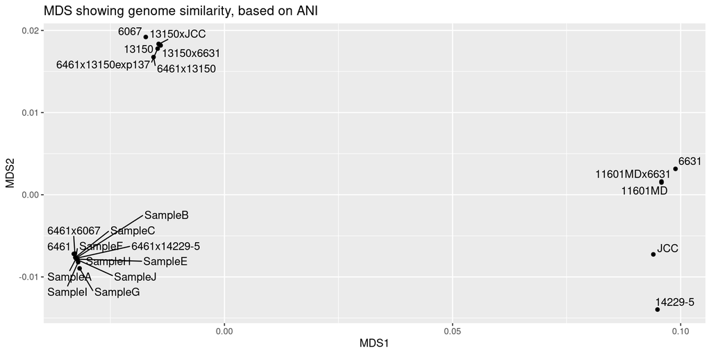

### Mating experiment table

This table lays out the mating experiments as they have been analysed below.

| experiment | donor_genome | recipient_genome | result_genome |
| --- | --- | --- | --- |
| experiment_1 | 14229-5 | 6461 | 6461x14229-5 |
| experiment_2 | 14229-5 | 6461 | SampleA |
| experiment_3 | 14229-5 | 6461 | SampleB |
| experiment_4 | 14229-5 | 6461 | SampleC |
| experiment_5 | 14229-5 | 6461 | SampleE |
| experiment_6 | 14229-5 | 6461 | SampleF |
| experiment_7 | 14229-5 | 6461 | SampleG |
| experiment_8 | 14229-5 | 6461 | SampleH |
| experiment_9 | 14229-5 | 6461 | SampleI |
| experiment_10 | 14229-5 | 6461 | SampleJ |
| experiment_11 | 6067 | 6461 | 6461x6067 |
| experiment_12 | 6461 | 13150 | 6461x13150 |
| experiment_13 | 6461 | 13150 | 6461x13150exp137 |
| experiment_14 | 6631 | 11601MD | 11601MDx6631 |
| experiment_15 | 6631 | 13150 | 13150x6631 |
| experiment_16 | JCC | 13150 | 13150xJCC |

## Results

Reporting results separately for each mating experiment.

For each experiment there will be the following items:

1. Table of ‘genomic islands’ (XXX_Results.tsv)
2. Table of transferred genes (XXX_transferred.tsv)
3. Table of deleted genes (XXX_deleted.tsv)
4. plot showing where genomic islands are found in the donor and result genomes.

The tables in this report only contain a subset of the columns for viewing ease.

### experiment_1 : 14229-5 + 6461 = 6461x14229-5

Transferred genomic islands

| island_ID | quat_cluster | num_genes | island_type | RESISTANCE | res_type | HGT_role |
| --- | --- | --- | --- | --- | --- | --- |
| 14229-5_18_1 | 137 | 1 | virulence | NA | NA | donor |
| 6461x14229-5_28_1 | 137 | 1 | virulence | NA | NA | result |
| 14229-5_17_1 | 138 | 6 | AMR | AMIKACIN;GENTAMICIN;KANAMYCIN;TOBRAMYCIN | aph(2’’)-If<100%> | donor |
| 6461x14229-5_29_1 | 138 | 6 | AMR | AMIKACIN;GENTAMICIN;KANAMYCIN;TOBRAMYCIN | aph(2’’)-If<100%> | result |

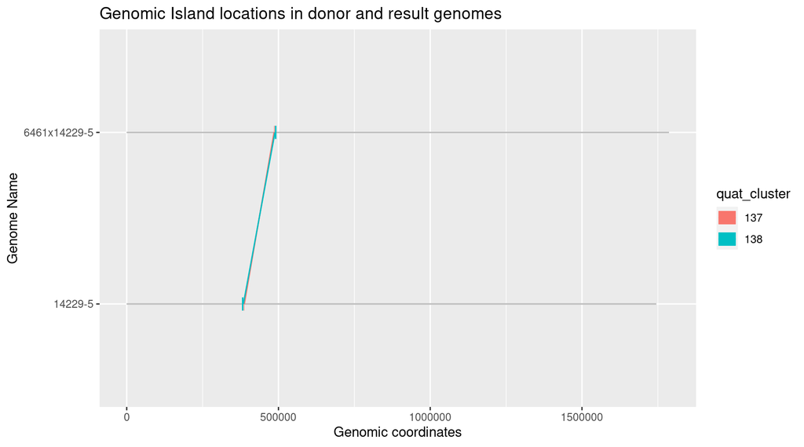

Transferred Genes

| Gene | all_Qclusters | Annotation | 14229-5 | 6461 | 6461x14229-5 |
| --- | --- | --- | --- | --- | --- |
| pseD_1 | 137 | protein PseD | DIHJAPKI_00380 | NA | LMDBFIGE_00469 |
| group_368 | 138 | hypothetical protein | DIHJAPKI_00378 | NA | LMDBFIGE_00471 |
| group_367 | 138 | IS1595 family transposase ISAcsp6 | DIHJAPKI_00377 | NA | LMDBFIGE_00472 |
| group_366 | 138 | hypothetical protein | DIHJAPKI_00376 | NA | LMDBFIGE_00473 |
| group_365 | 138 | hypothetical protein | DIHJAPKI_00375 | NA | LMDBFIGE_00474 |
| group_364 | 138 | IS1595 family transposase ISCco2 | DIHJAPKI_00374 | NA | LMDBFIGE_00475 |
| group_363 | 138 | IS200/IS605 family transposase IS605 | DIHJAPKI_00373 | NA | LMDBFIGE_00476 |

Deleted Genes

| Gene | all_Qclusters | Annotation | 14229-5 | 6461 | 6461x14229-5 |
| --- | --- | --- | --- | --- | --- |
| group_7 | 126 | two-component regulator | NA | EKEIMHEI_00302 | NA |
| group_2094 | 106 | protein PseD | NA | EKEIMHEI_00468 | NA |
| group_11 | 141 | hypothetical protein | NA | EKEIMHEI_00485 | NA |
| group_3495 | 118 | hypothetical protein | NA | EKEIMHEI_01923 | NA |

END experiment_1 : 14229-5 + 6461 = 6461x14229-5

### experiment_2 : 14229-5 + 6461 = SampleA

Transferred genomic islands

| island_ID | quat_cluster | num_genes | island_type | RESISTANCE | res_type | HGT_role |
| --- | --- | --- | --- | --- | --- | --- |
| 14229-5_18_1 | 137 | 1 | virulence | NA | NA | donor |
| SampleA_28_1 | 137 | 1 | virulence | NA | NA | result |
| 14229-5_17_1 | 138 | 6 | AMR | AMIKACIN;GENTAMICIN;KANAMYCIN;TOBRAMYCIN | aph(2’’)-If<100%> | donor |
| SampleA_29_1 | 138 | 6 | AMR | AMIKACIN;GENTAMICIN;KANAMYCIN;TOBRAMYCIN | aph(2’’)-If<100%> | result |

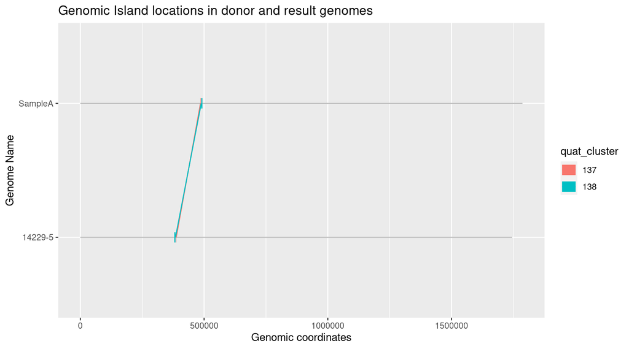

Transferred Genes

| Gene | all_Qclusters | Annotation | 14229-5 | 6461 | SampleA |
| --- | --- | --- | --- | --- | --- |
| pseD_4 | 137 | protein PseD | DIHJAPKI_00380 | NA | ILAKLKNP_00469 |
| group_368 | 138 | hypothetical protein | DIHJAPKI_00378 | NA | ILAKLKNP_00471 |
| group_367 | 138 | IS1595 family transposase ISAcsp6 | DIHJAPKI_00377 | NA | ILAKLKNP_00472 |
| group_366 | 138 | hypothetical protein | DIHJAPKI_00376 | NA | ILAKLKNP_00473 |
| group_365 | 138 | hypothetical protein | DIHJAPKI_00375 | NA | ILAKLKNP_00474 |
| group_364 | 138 | IS1595 family transposase ISCco2 | DIHJAPKI_00374 | NA | ILAKLKNP_00475 |
| group_363 | 138 | IS200/IS605 family transposase IS605 | DIHJAPKI_00373 | NA | ILAKLKNP_00476 |

Deleted Genes

| Gene | all_Qclusters | Annotation | 14229-5 | 6461 | SampleA |
| --- | --- | --- | --- | --- | --- |
| group_7 | 126 | two-component regulator | NA | EKEIMHEI_00302 | NA |
| group_2094 | 106 | protein PseD | NA | EKEIMHEI_00468 | NA |
| group_11 | 141 | hypothetical protein | NA | EKEIMHEI_00485 | NA |

END experiment_2 : 14229-5 + 6461 = SampleA

### experiment_3 : 14229-5 + 6461 = SampleB

Transferred genomic islands

| island_ID | quat_cluster | num_genes | island_type | RESISTANCE | res_type | HGT_role |
| --- | --- | --- | --- | --- | --- | --- |
| 14229-5_17_1 | 138 | 6 | AMR | AMIKACIN;GENTAMICIN;KANAMYCIN;TOBRAMYCIN | aph(2’’)-If<100%> | donor |
| SampleB_29_1 | 138 | 6 | AMR | AMIKACIN;GENTAMICIN;KANAMYCIN;TOBRAMYCIN | aph(2’’)-If<100%> | result |

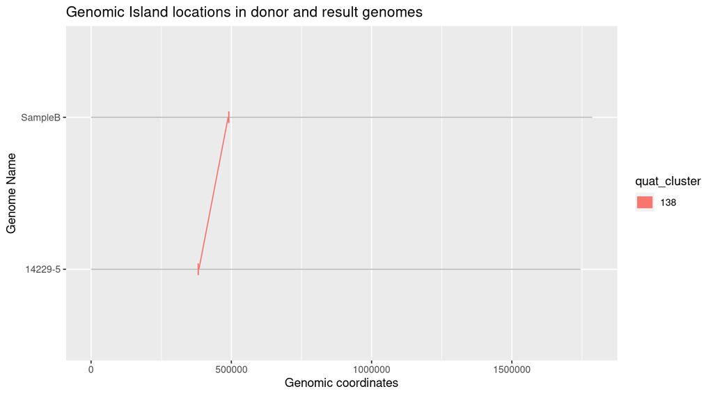

Transferred Genes

| Gene | all_Qclusters | Annotation | 14229-5 | 6461 | SampleB |
| --- | --- | --- | --- | --- | --- |
| group_367 | 138 | hypothetical protein | DIHJAPKI_00378 | NA | NPJCOLHL_00470 |
| group_366 | 138 | IS1595 family transposase ISAcsp6 | DIHJAPKI_00377 | NA | NPJCOLHL_00471 |
| group_365 | 138 | hypothetical protein | DIHJAPKI_00376 | NA | NPJCOLHL_00472 |
| group_364 | 138 | hypothetical protein | DIHJAPKI_00375 | NA | NPJCOLHL_00473 |
| group_363 | 138 | IS1595 family transposase ISCco2 | DIHJAPKI_00374 | NA | NPJCOLHL_00474 |
| group_362 | 138 | IS200/IS605 family transposase IS605 | DIHJAPKI_00373 | NA | NPJCOLHL_00475 |
| pseH | 16\|140 | N-acetyltransferase | DIHJAPKI_00369 | NA | NPJCOLHL_00479 |

Deleted Genes

| Gene | all_Qclusters | Annotation | 14229-5 | 6461 | SampleB |
| --- | --- | --- | --- | --- | --- |
| group_7 | 126 | two-component regulator | NA | EKEIMHEI_00302 | NA |
| group_2095 | 140 | N-acetyltransferase | NA | EKEIMHEI_00473 | NA |
| group_9 | 141 | hypothetical protein | NA | EKEIMHEI_00485 | NA |
| group_3478 | 118 | hypothetical protein | NA | EKEIMHEI_01923 | NA |

END experiment_3 : 14229-5 + 6461 = SampleB

### experiment_4 : 14229-5 + 6461 = SampleC

Transferred genomic islands

| island_ID | quat_cluster | num_genes | island_type | RESISTANCE | res_type | HGT_role |
| --- | --- | --- | --- | --- | --- | --- |
| 14229-5_17_1 | 138 | 6 | AMR | AMIKACIN;GENTAMICIN;KANAMYCIN;TOBRAMYCIN | aph(2’’)-If<100%> | donor |
| SampleC_29_1 | 138 | 6 | AMR | AMIKACIN;GENTAMICIN;KANAMYCIN;TOBRAMYCIN | aph(2’’)-If<100%> | result |

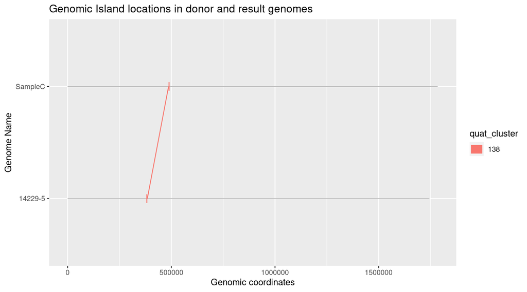

Transferred Genes

| Gene | all_Qclusters | Annotation | 14229-5 | 6461 | SampleC |
| --- | --- | --- | --- | --- | --- |
| group_366 | 138 | hypothetical protein | DIHJAPKI_00378 | NA | NDOBDCDD_00470 |
| group_365 | 138 | IS1595 family transposase ISAcsp6 | DIHJAPKI_00377 | NA | NDOBDCDD_00471 |
| group_364 | 138 | hypothetical protein | DIHJAPKI_00376 | NA | NDOBDCDD_00472 |
| group_363 | 138 | hypothetical protein | DIHJAPKI_00375 | NA | NDOBDCDD_00473 |
| group_362 | 138 | IS1595 family transposase ISCco2 | DIHJAPKI_00374 | NA | NDOBDCDD_00474 |
| group_361 | 138 | IS200/IS605 family transposase IS605 | DIHJAPKI_00373 | NA | NDOBDCDD_00475 |

Deleted Genes

| Gene | all_Qclusters | Annotation | 14229-5 | 6461 | SampleC |
| --- | --- | --- | --- | --- | --- |
| group_7 | 126 | two-component regulator | NA | EKEIMHEI_00302 | NA |
| flaA | 134 | flagellin A | NA | EKEIMHEI_00449 | NA |
| group_2079 | 134 | flagellin B | NA | EKEIMHEI_00450 | NA |
| group_2103 | 141 | hypothetical protein | NA | EKEIMHEI_00485 | NA |

END experiment_4 : 14229-5 + 6461 = SampleC

### experiment_5 : 14229-5 + 6461 = SampleE

Transferred genomic islands

| island_ID | quat_cluster | num_genes | island_type | RESISTANCE | res_type | HGT_role |
| --- | --- | --- | --- | --- | --- | --- |
| 14229-5_17_1 | 139 | 6 | AMR | AMIKACIN;GENTAMICIN;KANAMYCIN;TOBRAMYCIN | aph(2’’)-If<100%> | donor |
| SampleE_29_1 | 139 | 6 | AMR | AMIKACIN;GENTAMICIN;KANAMYCIN;TOBRAMYCIN | aph(2’’)-If<100%> | result |

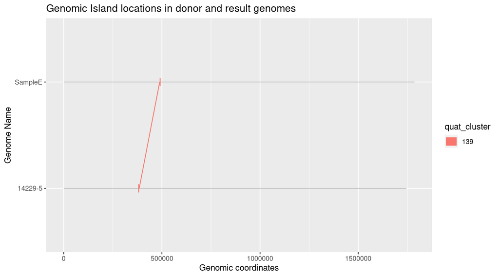

Transferred Genes

| Gene | all_Qclusters | Annotation | 14229-5 | 6461 | SampleE |
| --- | --- | --- | --- | --- | --- |
| group_369 | 139 | hypothetical protein | DIHJAPKI_00378 | NA | HACBDFIB_00471 |
| group_368 | 139 | IS1595 family transposase ISAcsp6 | DIHJAPKI_00377 | NA | HACBDFIB_00472 |
| group_367 | 139 | hypothetical protein | DIHJAPKI_00376 | NA | HACBDFIB_00473 |
| group_366 | 139 | hypothetical protein | DIHJAPKI_00375 | NA | HACBDFIB_00474 |
| group_365 | 139 | IS1595 family transposase ISCco2 | DIHJAPKI_00374 | NA | HACBDFIB_00475 |
| group_364 | 139 | IS200/IS605 family transposase IS605 | DIHJAPKI_00373 | NA | HACBDFIB_00476 |
| pseH | 16\|141 | N-acetyltransferase | DIHJAPKI_00369 | NA | HACBDFIB_00480 |
| pseG | 16\|141 | UDP-2,4-diacetamido-2,4, 6-trideoxy-beta-L-altropyranose hydrolase | DIHJAPKI_00368 | NA | HACBDFIB_00481 |
| pseF | 16\|141 | pseudaminic acid cytidylyltransferase | DIHJAPKI_00367 | NA | HACBDFIB_00482 |

Deleted Genes

| Gene | all_Qclusters | Annotation | 14229-5 | 6461 | SampleE |
| --- | --- | --- | --- | --- | --- |
| group_7 | 127 | two-component regulator | NA | EKEIMHEI_00302 | NA |
| group_2096 | 107 | N-acetyltransferase | NA | EKEIMHEI_00473 | NA |
| group_2097 | 107 | UDP-2,4-diacetamido-2,4, 6-trideoxy-beta-L-altropyranose hydrolase | NA | EKEIMHEI_00474 | NA |
| group_2098 | 107 | pseudaminic acid cytidylyltransferase | NA | EKEIMHEI_00475 | NA |
| group_11 | 142 | hypothetical protein | NA | EKEIMHEI_00485 | NA |

END experiment_5 : 14229-5 + 6461 = SampleE

### experiment_6 : 14229-5 + 6461 = SampleF

Transferred genomic islands

| island_ID | quat_cluster | num_genes | island_type | RESISTANCE | res_type | HGT_role |
| --- | --- | --- | --- | --- | --- | --- |
| 14229-5_20_1 | 141 | 1 | virulence | NA | NA | donor |
| SampleF_28_1 | 141 | 1 | virulence | NA | NA | result |
| 14229-5_19_1 | 142 | 6 | AMR | AMIKACIN;GENTAMICIN;KANAMYCIN;TOBRAMYCIN | aph(2’’)-If<100%> | donor |
| SampleF_29_1 | 142 | 6 | AMR | AMIKACIN;GENTAMICIN;KANAMYCIN;TOBRAMYCIN | aph(2’’)-If<100%> | result |

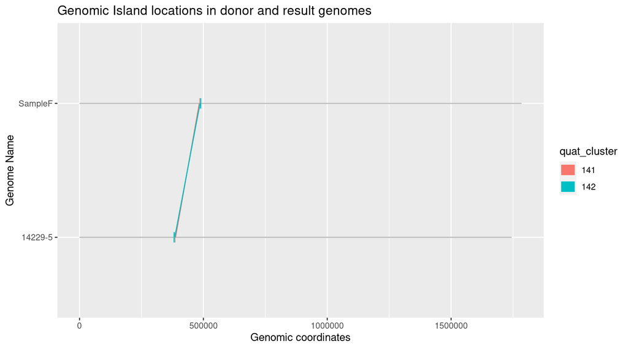

Transferred Genes

| Gene | all_Qclusters | Annotation | 14229-5 | 6461 | SampleF |
| --- | --- | --- | --- | --- | --- |
| pseD_1 | 141 | protein PseD | DIHJAPKI_00380 | NA | IDFMAPHC_00468 |
| group_371 | 142 | hypothetical protein | DIHJAPKI_00378 | NA | IDFMAPHC_00470 |
| group_370 | 142 | IS1595 family transposase ISAcsp6 | DIHJAPKI_00377 | NA | IDFMAPHC_00471 |
| group_369 | 142 | hypothetical protein | DIHJAPKI_00376 | NA | IDFMAPHC_00472 |
| group_368 | 142 | hypothetical protein | DIHJAPKI_00375 | NA | IDFMAPHC_00473 |
| group_367 | 142 | IS1595 family transposase ISCco2 | DIHJAPKI_00374 | NA | IDFMAPHC_00474 |
| group_366 | 142 | IS200/IS605 family transposase IS605 | DIHJAPKI_00373 | NA | IDFMAPHC_00475 |

Deleted Genes

| Gene | all_Qclusters | Annotation | 14229-5 | 6461 | SampleF |
| --- | --- | --- | --- | --- | --- |
| group_8 | 130 | two-component regulator | NA | EKEIMHEI_00302 | NA |
| flaA | 138 | flagellin A | NA | EKEIMHEI_00449 | NA |
| group_2084 | 138 | flagellin B | NA | EKEIMHEI_00450 | NA |
| group_2097 | 108 | protein PseD | NA | EKEIMHEI_00468 | NA |
| hisH_1 | 109 | imidazole glycerol phosphate synthase subunit HisH | DIHJAPKI_00371 | EKEIMHEI_00471 | NA |
| group_12 | 147 | hypothetical protein | NA | EKEIMHEI_00485 | NA |
| group_3367 | 122 | hypothetical protein | NA | EKEIMHEI_01888 | NA |
| group_3372 | 122 | hypothetical protein | NA | EKEIMHEI_01893 | NA |
| group_3373 | 122 | hypothetical protein | NA | EKEIMHEI_01894 | NA |
| group_3374 | 122 | hypothetical protein | NA | EKEIMHEI_01895 | NA |
| group_3375 | 122 | hypothetical protein | NA | EKEIMHEI_01896 | NA |
| group_3376 | 122 | hypothetical protein | NA | EKEIMHEI_01897 | NA |
| group_3377 | 122 | hypothetical protein | NA | EKEIMHEI_01898 | NA |
| virC1 | 122 | Protein virC1 | NA | EKEIMHEI_01899 | NA |
| group_3379 | 122 | hypothetical protein | NA | EKEIMHEI_01900 | NA |
| group_3380 | 122 | hypothetical protein | NA | EKEIMHEI_01901 | NA |
| vbhT | 122 | Protein adenylyltransferase VbhT | NA | EKEIMHEI_01902 | NA |
| traL | 122 | Protein TraL | NA | EKEIMHEI_01904 | NA |
| traG | 122 | Conjugal transfer protein TraG | NA | EKEIMHEI_01905 | NA |
| group_3384 | 122 | hypothetical protein | NA | EKEIMHEI_01906 | NA |
| group_3385 | 122 | hypothetical protein | NA | EKEIMHEI_01907 | NA |
| group_14 | 122 | hypothetical protein | NA | EKEIMHEI_01909 | NA |
| group_3398 | 107 | hypothetical protein | NA | EKEIMHEI_01922 | NA |
| group_3493 | 107 | hypothetical protein | NA | EKEIMHEI_01923 | NA |
| group_3399 | 107 | hypothetical protein | NA | EKEIMHEI_01924 | NA |

END experiment_6 : 14229-5 + 6461 = SampleF

### experiment_7 : 14229-5 + 6461 = SampleG

Transferred genomic islands

| island_ID | quat_cluster | num_genes | island_type | RESISTANCE | res_type | HGT_role |
| --- | --- | --- | --- | --- | --- | --- |
| 14229-5_20_1 | 136 | 7 | virulence | NA | NA | donor |
| SampleG_26_1 | 136 | 6 | virulence | NA | NA | result |
| 14229-5_17_1 | 139 | 6 | AMR | AMIKACIN;GENTAMICIN;KANAMYCIN;TOBRAMYCIN | aph(2’’)-If<100%> | donor |
| SampleG_29_1 | 139 | 6 | AMR | AMIKACIN;GENTAMICIN;KANAMYCIN;TOBRAMYCIN | aph(2’’)-If<100%> | result |

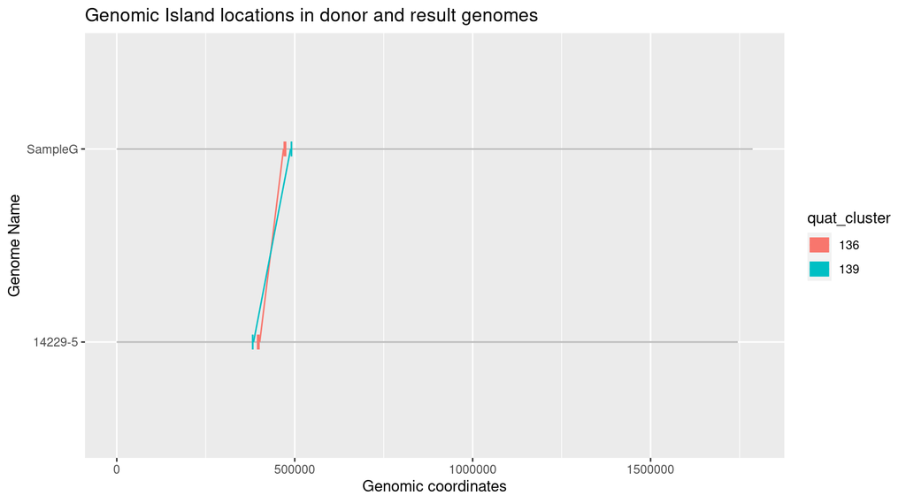

Transferred Genes

| Gene | all_Qclusters | Annotation | 14229-5 | 6461 | SampleG |
| --- | --- | --- | --- | --- | --- |
| group_385 | 21\|134 | hypothetical protein | DIHJAPKI_00403 | NA | BEGKIOMD_00439 |
| dxr | 20\|135 | 1-deoxy-D-xylulose 5-phosphate reductoisomerase | DIHJAPKI_00401 | NA | BEGKIOMD_00441 |
| group_383 | 20\|135 | periplasmic protein | DIHJAPKI_00400 | NA | BEGKIOMD_00442 |
| group_382 | 20\|135 | tRNA N6-adenosine threonylcarbamoyltransferase | DIHJAPKI_00399 | NA | BEGKIOMD_00443 |
| group_381 | 20\|135 | periplasmic protein | DIHJAPKI_00398 | NA | BEGKIOMD_00444 |
| pseD_1 | 136 | protein PseD | DIHJAPKI_00392 | NA | BEGKIOMD_00451 |
| pseD_3 | 136 | protein PseD | DIHJAPKI_00390 | NA | BEGKIOMD_00452 |
| pseD_2 | 136 | protein PseD | DIHJAPKI_00389 | NA | BEGKIOMD_00453 |
| ptmA | 136 | flagellin modification protein A | DIHJAPKI_00388 | NA | BEGKIOMD_00454 |
| ptmB | 136 | CMP-N,N’-diacetyllegionaminic acid synthase | DIHJAPKI_00387 | NA | BEGKIOMD_00455 |
| group_371 | 136 | isomerase | DIHJAPKI_00386 | NA | BEGKIOMD_00456 |
| neuB2 | 18\|137 | N,N’-diacetyllegionaminic acid synthase | DIHJAPKI_00383 | NA | BEGKIOMD_00459 |
| group_367 | 139 | hypothetical protein | DIHJAPKI_00378 | NA | BEGKIOMD_00470 |
| group_366 | 139 | IS1595 family transposase ISAcsp6 | DIHJAPKI_00377 | NA | BEGKIOMD_00471 |
| group_365 | 139 | hypothetical protein | DIHJAPKI_00376 | NA | BEGKIOMD_00472 |
| group_364 | 139 | hypothetical protein | DIHJAPKI_00375 | NA | BEGKIOMD_00473 |
| group_363 | 139 | IS1595 family transposase ISCco2 | DIHJAPKI_00374 | NA | BEGKIOMD_00474 |
| group_362 | 139 | IS200/IS605 family transposase IS605 | DIHJAPKI_00373 | NA | BEGKIOMD_00475 |
| pseH | 16\|141 | N-acetyltransferase | DIHJAPKI_00369 | NA | BEGKIOMD_00479 |
| pseG | 16\|141 | UDP-2,4-diacetamido-2,4, 6-trideoxy-beta-L-altropyranose hydrolase | DIHJAPKI_00368 | NA | BEGKIOMD_00480 |

Deleted Genes

| Gene | all_Qclusters | Annotation | 14229-5 | 6461 | SampleG |
| --- | --- | --- | --- | --- | --- |
| group_5 | 127 | two-component regulator | NA | EKEIMHEI_00302 | NA |
| group_2069 | 134 | fibronectin/fibrinogen-binding protein | NA | EKEIMHEI_00439 | NA |
| group_2070 | 134 | hypothetical protein | NA | EKEIMHEI_00440 | NA |
| group_2071 | 106 | 1-deoxy-D-xylulose 5-phosphate reductoisomerase | NA | EKEIMHEI_00442 | NA |
| group_2072 | 106 | periplasmic protein | NA | EKEIMHEI_00443 | NA |
| group_2073 | 106 | tRNA N6-adenosine threonylcarbamoyltransferase | NA | EKEIMHEI_00444 | NA |
| group_2074 | 106 | periplasmic protein | NA | EKEIMHEI_00445 | NA |
| group_2075 | 106 | hypothetical protein | NA | EKEIMHEI_00446 | NA |
| group_2080 | 107 | protein PseD | NA | EKEIMHEI_00452 | NA |
| group_2081 | 107 | protein PseD | NA | EKEIMHEI_00453 | NA |
| group_2082 | 107 | protein PseD | NA | EKEIMHEI_00454 | NA |
| group_2083 | 107 | flagellin modification protein A | NA | EKEIMHEI_00455 | NA |
| group_2084 | 107 | CMP-N,N’-diacetyllegionaminic acid synthase | NA | EKEIMHEI_00456 | NA |
| group_2085 | 107 | isomerase | NA | EKEIMHEI_00457 | NA |
| group_2086 | 137 | N,N’-diacetyllegionaminic acid synthase | NA | EKEIMHEI_00460 | NA |
| group_2093 | 141 | N-acetyltransferase | NA | EKEIMHEI_00473 | NA |
| group_2094 | 141 | UDP-2,4-diacetamido-2,4, 6-trideoxy-beta-L-altropyranose hydrolase | NA | EKEIMHEI_00474 | NA |

END experiment_7 : 14229-5 + 6461 = SampleG

### experiment_8 : 14229-5 + 6461 = SampleH

Transferred genomic islands

| island_ID | quat_cluster | num_genes | island_type | RESISTANCE | res_type | HGT_role |
| --- | --- | --- | --- | --- | --- | --- |
| 14229-5_17_1 | 138 | 6 | AMR | AMIKACIN;GENTAMICIN;KANAMYCIN;TOBRAMYCIN | aph(2’’)-If<100%> | donor |
| SampleH_29_1 | 138 | 6 | AMR | AMIKACIN;GENTAMICIN;KANAMYCIN;TOBRAMYCIN | aph(2’’)-If<100%> | result |

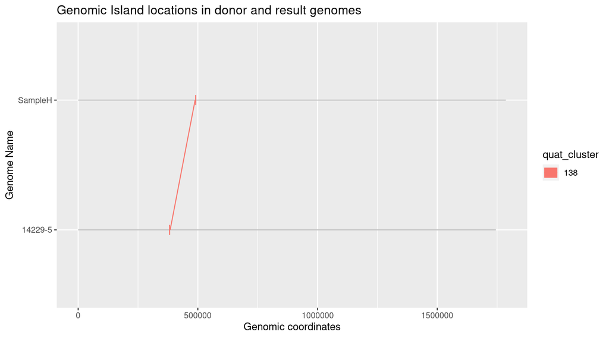

Transferred Genes

| Gene | all_Qclusters | Annotation | 14229-5 | 6461 | SampleH |
| --- | --- | --- | --- | --- | --- |
| group_368 | 138 | hypothetical protein | DIHJAPKI_00378 | NA | ACINBCJP_00471 |
| group_367 | 138 | IS1595 family transposase ISAcsp6 | DIHJAPKI_00377 | NA | ACINBCJP_00472 |
| group_366 | 138 | hypothetical protein | DIHJAPKI_00376 | NA | ACINBCJP_00473 |
| group_365 | 138 | hypothetical protein | DIHJAPKI_00375 | NA | ACINBCJP_00474 |
| group_364 | 138 | IS1595 family transposase ISCco2 | DIHJAPKI_00374 | NA | ACINBCJP_00475 |
| group_363 | 138 | IS200/IS605 family transposase IS605 | DIHJAPKI_00373 | NA | ACINBCJP_00476 |
| pseH | 16\|140 | N-acetyltransferase | DIHJAPKI_00369 | NA | ACINBCJP_00480 |
| pseG | 16\|140 | UDP-2,4-diacetamido-2,4, 6-trideoxy-beta-L-altropyranose hydrolase | DIHJAPKI_00368 | NA | ACINBCJP_00481 |

Deleted Genes

| Gene | all_Qclusters | Annotation | 14229-5 | 6461 | SampleH |
| --- | --- | --- | --- | --- | --- |
| group_7 | 126 | two-component regulator | NA | EKEIMHEI_00302 | NA |
| group_2095 | 140 | N-acetyltransferase | NA | EKEIMHEI_00473 | NA |
| group_2096 | 140 | UDP-2,4-diacetamido-2,4, 6-trideoxy-beta-L-altropyranose hydrolase | NA | EKEIMHEI_00474 | NA |
| group_11 | 141 | hypothetical protein | NA | EKEIMHEI_00485 | NA |
| group_3492 | 118 | hypothetical protein | NA | EKEIMHEI_01923 | NA |

END experiment_8 : 14229-5 + 6461 = SampleH

### experiment_9 : 14229-5 + 6461 = SampleI

Transferred genomic islands

| island_ID | quat_cluster | num_genes | island_type | RESISTANCE | res_type | HGT_role |
| --- | --- | --- | --- | --- | --- | --- |
| 14229-5_20_1 | 137 | 7 | virulence | NA | NA | donor |
| SampleI_26_1 | 137 | 6 | virulence | NA | NA | result |
| 14229-5_17_1 | 140 | 6 | AMR | AMIKACIN;GENTAMICIN;KANAMYCIN;TOBRAMYCIN | aph(2’’)-If<100%> | donor |
| SampleI_29_1 | 140 | 6 | AMR | AMIKACIN;GENTAMICIN;KANAMYCIN;TOBRAMYCIN | aph(2’’)-If<100%> | result |

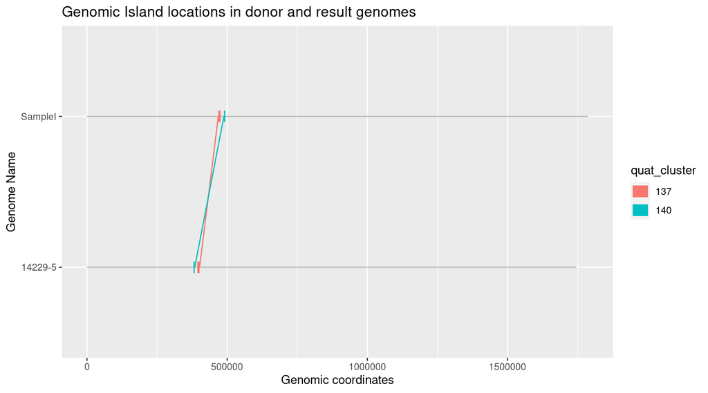

Transferred Genes

| Gene | all_Qclusters | Annotation | 14229-5 | 6461 | SampleI |
| --- | --- | --- | --- | --- | --- |
| pseD_1 | 137 | protein PseD | DIHJAPKI_00392 | NA | FJFOCOFI_00452 |
| pseD_2 | 137 | protein PseD | DIHJAPKI_00390 | NA | FJFOCOFI_00453 |
| group_376 | 137 | protein PseD | DIHJAPKI_00389 | NA | FJFOCOFI_00454 |
| ptmA | 137 | flagellin modification protein A | DIHJAPKI_00388 | NA | FJFOCOFI_00455 |
| ptmB | 137 | CMP-N,N’-diacetyllegionaminic acid synthase | DIHJAPKI_00387 | NA | FJFOCOFI_00456 |
| group_373 | 137 | isomerase | DIHJAPKI_00386 | NA | FJFOCOFI_00457 |
| group_369 | 140 | hypothetical protein | DIHJAPKI_00378 | NA | FJFOCOFI_00471 |
| group_368 | 140 | IS1595 family transposase ISAcsp6 | DIHJAPKI_00377 | NA | FJFOCOFI_00472 |
| group_367 | 140 | hypothetical protein | DIHJAPKI_00376 | NA | FJFOCOFI_00473 |
| group_366 | 140 | hypothetical protein | DIHJAPKI_00375 | NA | FJFOCOFI_00474 |
| group_365 | 140 | IS1595 family transposase ISCco2 | DIHJAPKI_00374 | NA | FJFOCOFI_00475 |
| group_364 | 140 | IS200/IS605 family transposase IS605 | DIHJAPKI_00373 | NA | FJFOCOFI_00476 |
| pseH | 16\|142 | N-acetyltransferase | DIHJAPKI_00369 | NA | FJFOCOFI_00480 |
| pseG | 16\|142 | UDP-2,4-diacetamido-2,4, 6-trideoxy-beta-L-altropyranose hydrolase | DIHJAPKI_00368 | NA | FJFOCOFI_00481 |
| pseF | 16\|142 | pseudaminic acid cytidylyltransferase | DIHJAPKI_00367 | NA | FJFOCOFI_00482 |

Deleted Genes

| Gene | all_Qclusters | Annotation | 14229-5 | 6461 | SampleI |
| --- | --- | --- | --- | --- | --- |
| group_7 | 128 | two-component regulator | NA | EKEIMHEI_00302 | NA |
| group_2080 | 136 | flagellin A | NA | EKEIMHEI_00449 | NA |
| group_2082 | 106 | protein PseD | NA | EKEIMHEI_00452 | NA |
| group_2083 | 106 | protein PseD | NA | EKEIMHEI_00453 | NA |
| pseD_3 | 106 | protein PseD | NA | EKEIMHEI_00454 | NA |
| group_2085 | 106 | flagellin modification protein A | NA | EKEIMHEI_00455 | NA |
| group_2086 | 106 | CMP-N,N’-diacetyllegionaminic acid synthase | NA | EKEIMHEI_00456 | NA |
| group_2087 | 106 | isomerase | NA | EKEIMHEI_00457 | NA |
| group_2094 | 107 | protein PseD | NA | EKEIMHEI_00468 | NA |
| group_2095 | 108 | N-acetyltransferase | NA | EKEIMHEI_00473 | NA |
| group_2096 | 108 | UDP-2,4-diacetamido-2,4, 6-trideoxy-beta-L-altropyranose hydrolase | NA | EKEIMHEI_00474 | NA |
| group_2097 | 108 | pseudaminic acid cytidylyltransferase | NA | EKEIMHEI_00475 | NA |
| group_2098 | 108 | hypothetical protein | NA | EKEIMHEI_00476 | NA |
| group_11 | 143 | hypothetical protein | NA | EKEIMHEI_00485 | NA |

END experiment_9 : 14229-5 + 6461 = SampleI

### experiment_10 : 14229-5 + 6461 = SampleJ

Transferred genomic islands

| island_ID | quat_cluster | num_genes | island_type | RESISTANCE | res_type | HGT_role |
| --- | --- | --- | --- | --- | --- | --- |
| 14229-5_18_1 | 137 | 1 | virulence | NA | NA | donor |
| SampleJ_28_1 | 137 | 1 | virulence | NA | NA | result |
| 14229-5_17_1 | 138 | 6 | AMR | AMIKACIN;GENTAMICIN;KANAMYCIN;TOBRAMYCIN | aph(2’’)-If<100%> | donor |
| SampleJ_29_1 | 138 | 6 | AMR | AMIKACIN;GENTAMICIN;KANAMYCIN;TOBRAMYCIN | aph(2’’)-If<100%> | result |

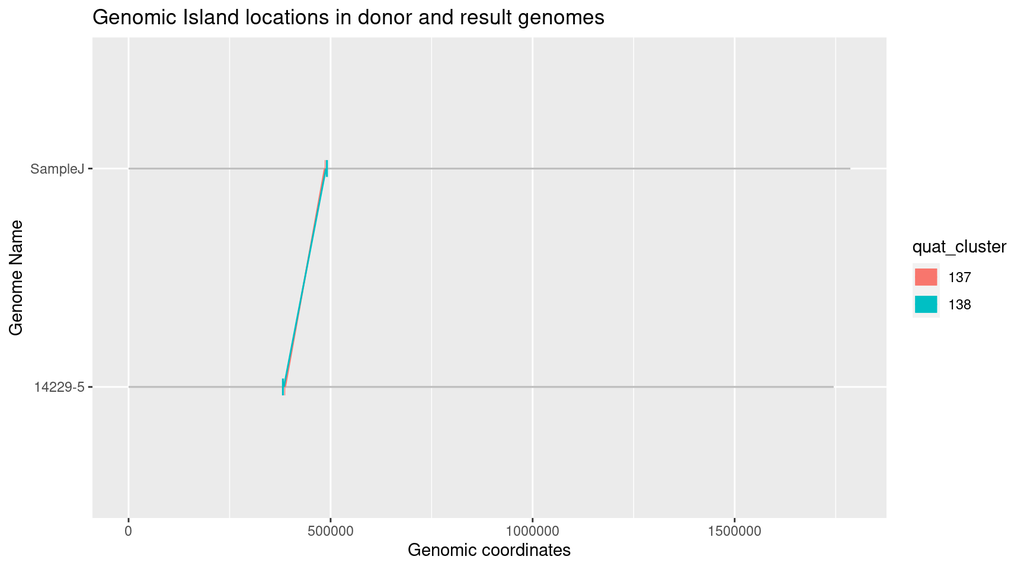

Transferred Genes

| Gene | all_Qclusters | Annotation | 14229-5 | 6461 | SampleJ |
| --- | --- | --- | --- | --- | --- |
| pseD_1 | 137 | protein PseD | DIHJAPKI_00380 | NA | LFKIBCJF_00468 |
| group_368 | 138 | hypothetical protein | DIHJAPKI_00378 | NA | LFKIBCJF_00470 |
| group_367 | 138 | IS1595 family transposase ISAcsp6 | DIHJAPKI_00377 | NA | LFKIBCJF_00471 |
| group_366 | 138 | hypothetical protein | DIHJAPKI_00376 | NA | LFKIBCJF_00472 |
| group_365 | 138 | hypothetical protein | DIHJAPKI_00375 | NA | LFKIBCJF_00473 |
| group_364 | 138 | IS1595 family transposase ISCco2 | DIHJAPKI_00374 | NA | LFKIBCJF_00474 |
| group_363 | 138 | IS200/IS605 family transposase IS605 | DIHJAPKI_00373 | NA | LFKIBCJF_00475 |
| pseH | 16\|140 | N-acetyltransferase | DIHJAPKI_00369 | NA | LFKIBCJF_00479 |

Deleted Genes

| Gene | all_Qclusters | Annotation | 14229-5 | 6461 | SampleJ |
| --- | --- | --- | --- | --- | --- |
| group_7 | 126 | two-component regulator | NA | EKEIMHEI_00302 | NA |
| pseD_4 | 106 | protein PseD | NA | EKEIMHEI_00468 | NA |
| group_2096 | 140 | N-acetyltransferase | NA | EKEIMHEI_00473 | NA |
| group_9 | 141 | hypothetical protein | NA | EKEIMHEI_00485 | NA |
| group_3473 | 118 | hypothetical protein | NA | EKEIMHEI_01923 | NA |

END experiment_10 : 14229-5 + 6461 = SampleJ

### experiment_11 : 6067 + 6461 = 6461x6067

Transferred genomic islands

| island_ID | quat_cluster | num_genes | island_type | RESISTANCE | res_type | HGT_role |
| --- | --- | --- | --- | --- | --- | --- |
| 6067_43_1 | 404 | 2 | AMR | BETA-LACTAM | blaOXA-605<99.38%> | donor |
| 6461x6067_215_1 | 404 | 2 | AMR | BETA-LACTAM | blaOXA-605<99.38%> | result |
| 6067_42_1 | 405 | 1 | unknown | NA | NA | donor |
| 6461x6067_216_1 | 405 | 1 | unknown | NA | NA | result |
| 6067_41_1 | 406 | 3 | unknown | NA | NA | donor |
| 6461x6067_217_1 | 406 | 3 | unknown | NA | NA | result |
| 6067_40_1 | 407 | 4 | unknown | NA | NA | donor |
| 6461x6067_218_1 | 407 | 4 | unknown | NA | NA | result |

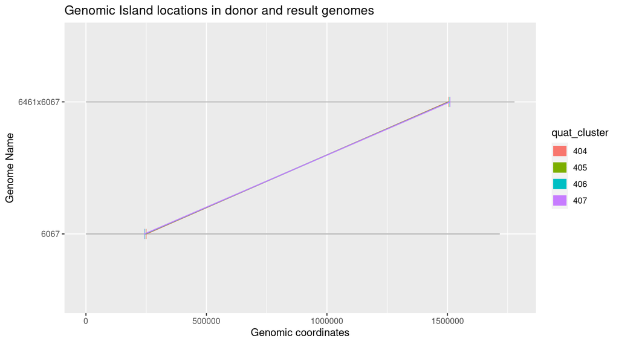

Transferred Genes

| Gene | all_Qclusters | Annotation | 6067 | 6461 | 6461x6067 |
| --- | --- | --- | --- | --- | --- |
| modC | 404 | molybdenum ABC transporter ATP-binding protein | HGOBFKMF_00253 | NA | NEPBBGAL_01546 |
| group_177 | 404 | beta-lactamase | HGOBFKMF_00252 | NA | NEPBBGAL_01547 |
| group_176 | 405 | acetyltransferase | HGOBFKMF_00248 | NA | NEPBBGAL_01551 |
| pgtP_3 | 406 | Phosphoglycerate transporter protein | HGOBFKMF_00245 | NA | NEPBBGAL_01554 |
| pgtP_2 | 406 | Phosphoglycerate transporter protein | HGOBFKMF_00244 | NA | NEPBBGAL_01555 |
| pgtP_1 | 406 | Phosphoglycerate transporter protein | HGOBFKMF_00243 | NA | NEPBBGAL_01556 |
| group_172 | 407 | cytolethal distending toxin B | HGOBFKMF_00241 | NA | NEPBBGAL_01558 |
| cdtB_2 | 407 | cytolethal distending toxin B | HGOBFKMF_00240 | NA | NEPBBGAL_01559 |
| cdtB_3 | 407 | cytolethal distending toxin B | HGOBFKMF_00239 | NA | NEPBBGAL_01560 |

Deleted Genes

| Gene | all_Qclusters | Annotation | 6067 | 6461 | 6461x6067 |
| --- | --- | --- | --- | --- | --- |
| group_5 | 274 | two-component regulator | NA | EKEIMHEI_00301 | NA |
| group_31 | 518 | hypothetical protein | NA | EKEIMHEI_00485 | NA |
| group_1357 | 270 | molybdenum ABC transporter ATP-binding protein | NA | EKEIMHEI_01545 | NA |
| group_1358 | 270 | hypothetical protein | NA | EKEIMHEI_01546 | NA |
| group_1359 | 270 | hypothetical protein | NA | EKEIMHEI_01547 | NA |
| group_1360 | 270 | isomerase | NA | EKEIMHEI_01548 | NA |
| group_1361 | 270 | hypothetical protein | NA | EKEIMHEI_01549 | NA |
| group_1362 | 270 | hypothetical protein | NA | EKEIMHEI_01550 | NA |
| group_1363 | 270 | hypothetical protein | NA | EKEIMHEI_01551 | NA |
| group_1364 | 271 | acetyltransferase | NA | EKEIMHEI_01555 | NA |
| group_1365 | 272 | Phosphoglycerate transporter protein | NA | EKEIMHEI_01558 | NA |
| group_1366 | 272 | hypothetical protein | NA | EKEIMHEI_01559 | NA |
| group_1367 | 272 | Phosphoglycerate transporter protein | NA | EKEIMHEI_01560 | NA |
| cdtB | 273 | cytolethal distending toxin B | NA | EKEIMHEI_01562 | NA |

END experiment_11 : 6067 + 6461 = 6461x6067

### experiment_12 : 6461 + 13150 = 6461x13150

Transferred genomic islands

| island_ID | quat_cluster | num_genes | island_type | RESISTANCE | res_type | HGT_role |
| --- | --- | --- | --- | --- | --- | --- |
| 6461_105_1 | 325 | 3 | unknown | NA | NA | donor |
| 6461x13150_145_1 | 325 | 3 | unknown | NA | NA | result |
| 6461_98_1 | 333 | 6 | unknown | NA | NA | donor |
| 6461x13150_152_1 | 333 | 6 | unknown | NA | NA | result |
| 13150_153_1 | 334 | 2 | unknown | NA | NA | recipient |
| 6461_97_1 | 334 | 2 | unknown | NA | NA | donor |
| 6461x13150_153_1 | 334 | 2 | unknown | NA | NA | result |
| 6461_92_1 | 339 | 2 | unknown | NA | NA | donor |
| 6461x13150_158_1 | 339 | 2 | unknown | NA | NA | result |
| 6461_91_1 | 340 | 1 | unknown | NA | NA | donor |
| 6461x13150_159_1 | 340 | 1 | unknown | NA | NA | result |
| 6461_90_1 | 342 | 1 | unknown | NA | NA | donor |
| 6461x13150_160_1 | 342 | 1 | unknown | NA | NA | result |
| 6461_89_1 | 343 | 4 | unknown | NA | NA | donor |
| 6461x13150_161_1 | 343 | 4 | unknown | NA | NA | result |
| 6461_85_1 | 347 | 1 | unknown | NA | NA | donor |
| 6461x13150_165_1 | 347 | 1 | unknown | NA | NA | result |
| 6461_84_1 | 348 | 1 | unknown | NA | NA | donor |
| 6461x13150_166_1 | 348 | 1 | unknown | NA | NA | result |
| 6461_83_1 | 349 | 1 | unknown | NA | NA | donor |
| 6461x13150_167_1 | 349 | 1 | unknown | NA | NA | result |
| 6461_24_1 | 408 | 5 | unknown | NA | NA | donor |
| 6461x13150_22_1 | 408 | 5 | unknown | NA | NA | result |
| 6461_25_1 | 419 | 2 | unknown | NA | NA | donor |
| 6461x13150_23_1 | 419 | 2 | unknown | NA | NA | result |
| 6461_26_1 | 430 | 2 | unknown | NA | NA | donor |
| 6461x13150_24_1 | 430 | 2 | unknown | NA | NA | result |
| 6461_27_1 | 441 | 2 | AMR | TETRACYCLINE | tet(O)<99.9%> | donor |
| 6461x13150_25_1 | 441 | 2 | AMR | TETRACYCLINE | tet(O)<99.9%> | result |
| 6461_28_1 | 452 | 2 | unknown | NA | NA | donor |
| 6461x13150_26_1 | 452 | 2 | unknown | NA | NA | result |
| 6461_29_1 | 457 | 1 | unknown | NA | NA | donor |
| 6461x13150_27_1 | 457 | 1 | unknown | NA | NA | result |
| 6461_30_1 | 458 | 3 | unknown | NA | NA | donor |
| 6461x13150_28_1 | 458 | 3 | unknown | NA | NA | result |
| 6461_31_1 | 459 | 1 | unknown | NA | NA | donor |
| 6461x13150_29_1 | 459 | 1 | unknown | NA | NA | result |

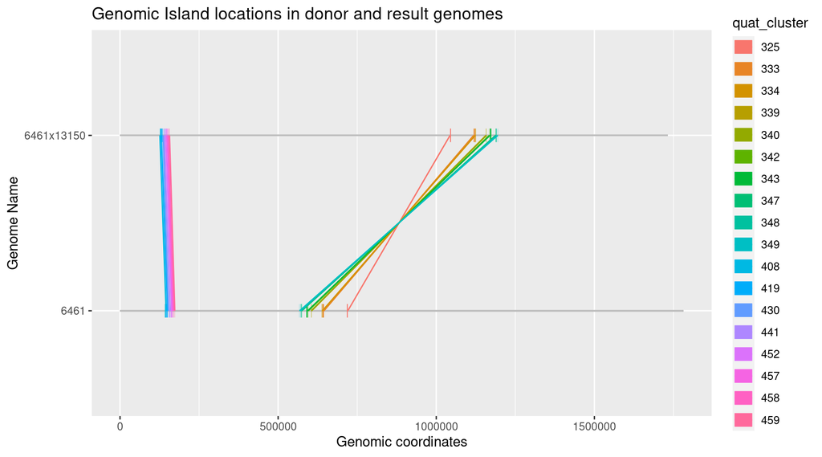

Transferred Genes

| Gene | all_Qclusters | Annotation | 13150 | 6461 | 6461x13150 |
| --- | --- | --- | --- | --- | --- |
| rnc | 408 | ribonuclease III | NA | EKEIMHEI_00132 | AGLJFKNC_00116 |
| aroC | 408 | chorismate synthase | NA | EKEIMHEI_00133 | AGLJFKNC_00117 |
| group_895 | 408 | hypothetical protein | NA | EKEIMHEI_00134 | AGLJFKNC_00118 |
| group_896 | 408 | hypothetical protein | NA | EKEIMHEI_00135 | AGLJFKNC_00119 |
| group_897 | 408 | hypothetical protein | NA | EKEIMHEI_00136 | AGLJFKNC_00120 |
| group_898 | 419 | hypothetical protein | NA | EKEIMHEI_00138 | AGLJFKNC_00122 |
| fhaC_1 | 419 | Filamentous hemagglutinin transporter protein FhaC | NA | EKEIMHEI_00139 | AGLJFKNC_00123 |
| group_900 | 430 | periplasmic protein | NA | EKEIMHEI_00142 | AGLJFKNC_00126 |
| group_901 | 430 | hypothetical protein | NA | EKEIMHEI_00143 | AGLJFKNC_00127 |
| group_902 | 441 | hypothetical protein | NA | EKEIMHEI_00147 | AGLJFKNC_00131 |
| fusA_1 | 441 | elongation factor G | NA | EKEIMHEI_00148 | AGLJFKNC_00132 |
| sdaC | 452 | amino acid transporter | NA | EKEIMHEI_00150 | AGLJFKNC_00134 |
| sdaA | 452 | L-serine dehydratase | NA | EKEIMHEI_00151 | AGLJFKNC_00135 |
| group_905 | 457 | hypothetical protein | NA | EKEIMHEI_00154 | AGLJFKNC_00138 |
| group_906 | 458 | iron-binding protein | NA | EKEIMHEI_00161 | AGLJFKNC_00145 |
| group_907 | 458 | iron-binding protein | NA | EKEIMHEI_00162 | AGLJFKNC_00146 |
| group_908 | 458 | iron-binding protein | NA | EKEIMHEI_00163 | AGLJFKNC_00147 |
| group_909 | 459 | radical SAM domain-containing protein | NA | EKEIMHEI_00166 | AGLJFKNC_00150 |
| folC | 325 | bifunctional folylpolyglutamate synthase/dihydrofolate synthase | NA | EKEIMHEI_00716 | AGLJFKNC_01095 |
| group_1166 | 325 | hypothetical protein | NA | EKEIMHEI_00715 | AGLJFKNC_01096 |
| group_1165 | 325 | lipoprotein | NA | EKEIMHEI_00714 | AGLJFKNC_01097 |
| group_1126 | 333 | hypothetical protein | NA | EKEIMHEI_00641 | AGLJFKNC_01168 |
| group_1125 | 333 | integral membrane protein | NA | EKEIMHEI_00640 | AGLJFKNC_01169 |
| group_1124 | 333 | integral membrane protein | NA | EKEIMHEI_00639 | AGLJFKNC_01170 |
| ldh | 333 | L-lactate dehydrogenase | NA | EKEIMHEI_00638 | AGLJFKNC_01171 |
| group_1122 | 333 | integral membrane protein | NA | EKEIMHEI_00637 | AGLJFKNC_01172 |
| ppi | 333 | peptidyl-prolyl cis-trans isomerase | NA | EKEIMHEI_00636 | AGLJFKNC_01173 |
| group_1120 | 334 | multidrug resistance protein | NA | EKEIMHEI_00633 | AGLJFKNC_01176 |
| group_1107 | 339 | carbon-nitrogen hydrolase | NA | EKEIMHEI_00600 | AGLJFKNC_01208 |
| group_1106 | 339 | hypothetical protein | NA | EKEIMHEI_00599 | AGLJFKNC_01209 |
| group_1105 | 340 | hypothetical protein | NA | EKEIMHEI_00597 | AGLJFKNC_01211 |
| group_1104 | 342 | exporting protein | NA | EKEIMHEI_00588 | AGLJFKNC_01220 |
| group_1103 | 343 | laccase domain-containing protein | NA | EKEIMHEI_00585 | AGLJFKNC_01223 |
| ribA_2 | 343 | riboflavin synthase subunit alpha | NA | EKEIMHEI_00584 | AGLJFKNC_01224 |
| group_1101 | 343 | periplasmic protein | NA | EKEIMHEI_00583 | AGLJFKNC_01225 |
| groES | 343 | co-chaperonin GroES | NA | EKEIMHEI_00582 | AGLJFKNC_01226 |
| group_1089 | 265\|346 | hypothetical protein | NA | EKEIMHEI_00568 | AGLJFKNC_01236 |
| group_1088 | 265\|346 | hypothetical protein | NA | EKEIMHEI_00567 | AGLJFKNC_01237 |
| group_1087 | 347 | two-component sensor histidine kinase | NA | EKEIMHEI_00565 | AGLJFKNC_01239 |
| htrA | 348 | serine protease | NA | EKEIMHEI_00563 | AGLJFKNC_01241 |
| group_1085 | 349 | HAD-superfamily hydrolase | NA | EKEIMHEI_00558 | AGLJFKNC_01246 |
| group_1084 | 264\|350 | peptidase M23 family protein | NA | EKEIMHEI_00556 | AGLJFKNC_01248 |

Deleted Genes

| Gene | all_Qclusters | Annotation | 13150 | 6461 | 6461x13150 |
| --- | --- | --- | --- | --- | --- |
| lctP_2 | 1 | L-lactate permease | PGHKFEJK_00074 | NA | NA |
| group_128 | 13 | ribonuclease III | PGHKFEJK_00117 | NA | NA |
| group_129 | 13 | chorismate synthase | PGHKFEJK_00118 | NA | NA |
| group_130 | 13 | hypothetical protein | PGHKFEJK_00119 | NA | NA |
| group_131 | 14 | hypothetical protein | PGHKFEJK_00121 | NA | NA |
| fhaB | 14 | Filamentous hemagglutinin | PGHKFEJK_00122 | NA | NA |
| group_133 | 14 | hypothetical protein | PGHKFEJK_00123 | NA | NA |
| group_134 | 15 | periplasmic protein | PGHKFEJK_00126 | NA | NA |
| group_135 | 15 | hypothetical protein | PGHKFEJK_00127 | NA | NA |
| group_136 | 16 | amino acid transporter | PGHKFEJK_00132 | NA | NA |
| group_137 | 16 | L-serine dehydratase | PGHKFEJK_00133 | NA | NA |
| group_138 | 17 | hypothetical protein | PGHKFEJK_00136 | NA | NA |
| group_139 | 18 | iron-binding protein | PGHKFEJK_00143 | NA | NA |
| group_140 | 18 | iron-binding protein | PGHKFEJK_00144 | NA | NA |
| group_141 | 19 | radical SAM domain-containing protein | PGHKFEJK_00147 | NA | NA |
| apt | 56 | adenine phosphoribosyltransferase | PGHKFEJK_00888 | EKEIMHEI_00918 | NA |
| group_423 | 2 | bifunctional folylpolyglutamate synthase/dihydrofolate synthase | PGHKFEJK_01090 | NA | NA |
| group_424 | 2 | hypothetical protein | PGHKFEJK_01091 | NA | NA |
| group_425 | 2 | lipoprotein | PGHKFEJK_01092 | NA | NA |
| group_462 | 3 | hypothetical protein | PGHKFEJK_01163 | NA | NA |
| group_463 | 3 | integral membrane protein | PGHKFEJK_01164 | NA | NA |
| group_464 | 3 | integral membrane protein | PGHKFEJK_01165 | NA | NA |
| group_465 | 3 | L-lactate dehydrogenase | PGHKFEJK_01166 | NA | NA |
| group_466 | 3 | integral membrane protein | PGHKFEJK_01167 | NA | NA |
| group_467 | 3 | periplasmic protein | PGHKFEJK_01168 | NA | NA |
| omp50 | 3 | outer membrane protein | PGHKFEJK_01169 | NA | NA |
| group_469 | 3 | peptidyl-prolyl cis-trans isomerase | PGHKFEJK_01170 | NA | NA |
| group_470 | 334 | multidrug resistance protein | PGHKFEJK_01173 | NA | NA |
| group_482 | 4 | carbon-nitrogen hydrolase | PGHKFEJK_01205 | NA | NA |
| group_483 | 5 | hypothetical protein | PGHKFEJK_01207 | NA | NA |
| group_16 | 5 | hypothetical protein | PGHKFEJK_01208 | NA | NA |
| group_484 | 6 | hypothetical protein | PGHKFEJK_01210 | NA | NA |
| group_485 | 7 | exporting protein | PGHKFEJK_01218 | NA | NA |
| group_486 | 8 | laccase domain-containing protein | PGHKFEJK_01221 | NA | NA |
| group_487 | 8 | riboflavin synthase subunit alpha | PGHKFEJK_01222 | NA | NA |
| group_488 | 8 | periplasmic protein | PGHKFEJK_01223 | NA | NA |
| group_489 | 8 | co-chaperonin GroES | PGHKFEJK_01224 | NA | NA |
| group_495 | 9 | periplasmic protein | PGHKFEJK_01233 | NA | NA |
| group_496 | 9 | hypothetical protein | PGHKFEJK_01234 | NA | NA |
| group_497 | 9 | hypothetical protein | PGHKFEJK_01235 | NA | NA |
| group_498 | 10 | two-component sensor histidine kinase | PGHKFEJK_01237 | NA | NA |
| group_499 | 11 | serine protease | PGHKFEJK_01239 | NA | NA |
| group_500 | 12 | HAD-superfamily hydrolase | PGHKFEJK_01244 | NA | NA |
| group_501 | 350 | peptidase M23 family protein | PGHKFEJK_01246 | NA | NA |
| group_502 | 350 | hypothetical protein | PGHKFEJK_01247 | NA | NA |
| group_19 | 362 | Putative polysaccharide biosynthesis protein with aminopeptidase-like domain protein | PGHKFEJK_01323 | NA | NA |
| group_537 | 364 | hypothetical protein | PGHKFEJK_01333 | NA | NA |
| group_541 | 364 | hypothetical protein | PGHKFEJK_01337 | NA | NA |

END experiment_12 : 6461 + 13150 = 6461x13150

### experiment_13 : 6461 + 13150 = 6461x13150exp137

Transferred genomic islands

| island_ID | quat_cluster | num_genes | island_type | RESISTANCE | res_type | HGT_role |
| --- | --- | --- | --- | --- | --- | --- |
| 6461_63_1 | 371 | 9 | virulence | NA | NA | donor |
| 6461x13150exp137_186_1 | 371 | 11 | virulence | NA | NA | result |
| 6461_25_1 | 420 | 1 | unknown | NA | NA | donor |
| 6461x13150exp137_23_1 | 420 | 1 | unknown | NA | NA | result |
| 6461_26_1 | 431 | 2 | unknown | NA | NA | donor |
| 6461x13150exp137_24_1 | 431 | 2 | unknown | NA | NA | result |

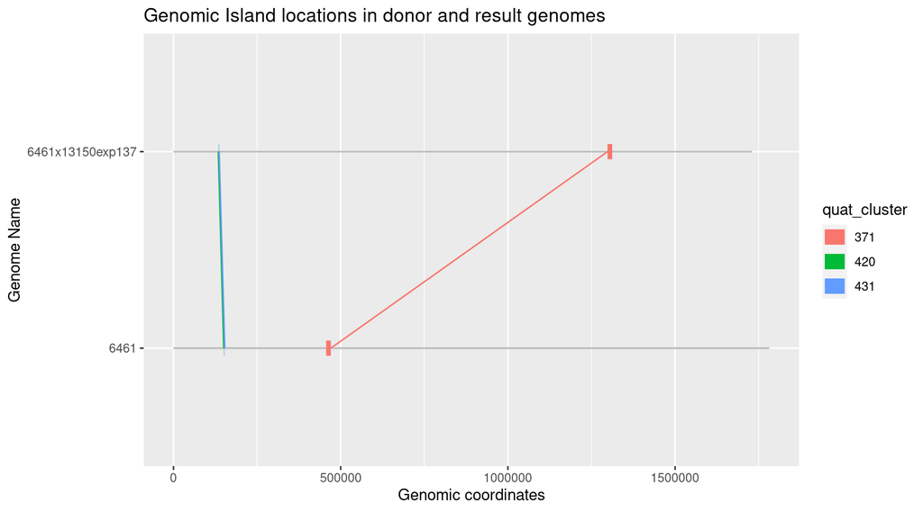

Transferred Genes

| Gene | all_Qclusters | Annotation | 13150 | 6461 | 6461x13150exp137 |
| --- | --- | --- | --- | --- | --- |
| fhaC | 420 | Filamentous hemagglutinin transporter protein FhaC | NA | EKEIMHEI_00139 | LOEINDNJ_00121 |
| group_896 | 431 | periplasmic protein | NA | EKEIMHEI_00142 | LOEINDNJ_00124 |
| group_897 | 431 | hypothetical protein | NA | EKEIMHEI_00143 | LOEINDNJ_00125 |
| flaB | 371 | flagellin B | NA | EKEIMHEI_00450 | LOEINDNJ_01365 |
| flaA | 371 | flagellin A | NA | EKEIMHEI_00449 | LOEINDNJ_01366 |
| group_1025 | 371 | motility protein | NA | EKEIMHEI_00448 | LOEINDNJ_01367 |
| group_1024 | 371 | motility protein | NA | EKEIMHEI_00447 | LOEINDNJ_01368 |
| group_29 | 371 | hypothetical protein | NA | EKEIMHEI_00446 | LOEINDNJ_01369 |
| group_1023 | 371 | periplasmic protein | NA | EKEIMHEI_00445 | LOEINDNJ_01371 |
| group_1022 | 371 | tRNA N6-adenosine threonylcarbamoyltransferase | NA | EKEIMHEI_00444 | LOEINDNJ_01372 |

Deleted Genes

| Gene | all_Qclusters | Annotation | 13150 | 6461 | 6461x13150exp137 |
| --- | --- | --- | --- | --- | --- |
| lctP_2 | 1 | L-lactate permease | PGHKFEJK_00074 | NA | NA |
| group_131 | 3 | hypothetical protein | PGHKFEJK_00121 | NA | NA |
| group_132 | 4 | hypothetical protein | PGHKFEJK_00123 | NA | NA |
| group_133 | 5 | periplasmic protein | PGHKFEJK_00126 | NA | NA |
| group_134 | 5 | hypothetical protein | PGHKFEJK_00127 | NA | NA |
| group_18 | 362 | Putative polysaccharide biosynthesis protein with aminopeptidase-like domain protein | PGHKFEJK_01323 | NA | NA |
| group_537 | 363 | hypothetical protein | PGHKFEJK_01333 | NA | NA |
| group_20 | 363 | hypothetical protein | PGHKFEJK_01335 | NA | NA |
| group_22 | 363 | hypothetical protein | PGHKFEJK_01337 | NA | NA |
| group_558 | 2 | flagellin B | PGHKFEJK_01369 | NA | NA |
| group_559 | 2 | flagellin A | PGHKFEJK_01370 | NA | NA |
| group_560 | 2 | motility protein | PGHKFEJK_01371 | NA | NA |
| group_561 | 2 | motility protein | PGHKFEJK_01372 | NA | NA |
| group_562 | 2 | hypothetical protein | PGHKFEJK_01373 | NA | NA |
| group_563 | 2 | periplasmic protein | PGHKFEJK_01374 | NA | NA |
| group_564 | 2 | tRNA N6-adenosine threonylcarbamoyltransferase | PGHKFEJK_01375 | NA | NA |
| group_765 | 6 | hypothetical protein | PGHKFEJK_01846 | NA | NA |
| virB4 | 455 | Type IV secretion system protein virB4 | PGHKFEJK_01875 | NA | NA |

END experiment_13 : 6461 + 13150 = 6461x13150exp137

### experiment_14 : 6631 + 11601MD = 11601MDx6631

Transferred genomic islands

| island_ID | quat_cluster | num_genes | island_type | RESISTANCE | res_type | HGT_role |
| --- | --- | --- | --- | --- | --- | --- |

[1] “nothing to plot”

Transferred Genes

| Gene | all_Qclusters | Annotation | 11601MD | 11601MDx6631 | 6631 |
| --- | --- | --- | --- | --- | --- |

Deleted Genes

| Gene | all_Qclusters | Annotation | 11601MD | 11601MDx6631 | 6631 |
| --- | --- | --- | --- | --- | --- |
| wlaN_1 | 78 | beta-1,3 galactosyltransferase | NDOAKFMB_01261 | NA | NA |
| wlaN_2 | 78 | beta-1,3 galactosyltransferase | NDOAKFMB_01262 | NA | NA |
| group_506 | 105 | Methionyl-tRNA formyltransferase | NDOAKFMB_01426 | NA | NA |

END experiment_14 : 6631 + 11601MD = 11601MDx6631

### experiment_15 : 6631 + 13150 = 13150x6631

Transferred genomic islands

| island_ID | quat_cluster | num_genes | island_type | RESISTANCE | res_type | HGT_role |
| --- | --- | --- | --- | --- | --- | --- |

[1] “nothing to plot”

Transferred Genes

| Gene | all_Qclusters | Annotation | 13150 | 13150x6631 | 6631 |
| --- | --- | --- | --- | --- | --- |
| group_1638 | 58\|184 | exporting protein | NA | BACMIICJ_00451 | KINOJHBP_00460 |
| group_1639 | 58\|184 | methyltransferase domain-containing protein | NA | BACMIICJ_00452 | KINOJHBP_00461 |
| group_1640 | 58\|184 | hypothetical protein | NA | BACMIICJ_00453 | KINOJHBP_00462 |
| group_1641 | 58\|184 | lipoprotein | NA | BACMIICJ_00454 | KINOJHBP_00463 |
| trpC | 58\|184 | Indole-3-glycerol phosphate synthase | NA | BACMIICJ_00455 | KINOJHBP_00464 |

Deleted Genes

| Gene | all_Qclusters | Annotation | 13150 | 13150x6631 | 6631 |
| --- | --- | --- | --- | --- | --- |
| lctP_2 | 108 | L-lactate permease | PGHKFEJK_00074 | NA | NA |
| group_407 | 58 | hypothetical protein | PGHKFEJK_00452 | NA | NA |
| group_408 | 58 | methyltransferase domain-containing protein | PGHKFEJK_00453 | NA | NA |
| group_409 | 58 | hypothetical protein | PGHKFEJK_00454 | NA | NA |
| group_410 | 58 | lipoprotein | PGHKFEJK_00455 | NA | NA |
| group_411 | 58 | Indole-3-glycerol phosphate synthase | PGHKFEJK_00456 | NA | NA |
| group_1183 | 112 | hypothetical protein | PGHKFEJK_01333 | NA | NA |
| group_1187 | 112 | hypothetical protein | PGHKFEJK_01337 | NA | NA |
| group_1610 | 29 | hypothetical protein | PGHKFEJK_01846 | NA | NA |

END experiment_15 : 6631 + 13150 = 13150x6631

### experiment_16 : JCC + 13150 = 13150xJCC

Transferred genomic islands

| island_ID | quat_cluster | num_genes | island_type | RESISTANCE | res_type | HGT_role |
| --- | --- | --- | --- | --- | --- | --- |

[1] “nothing to plot”

Transferred Genes

| Gene | all_Qclusters | Annotation | 13150 | 13150xJCC | JCC |
| --- | --- | --- | --- | --- | --- |
| group_1626 | 43\|185 | hypothetical protein | NA | CEKLBJOM_01869 | BLFAMBHF_01971 |
| group_1627 | 43\|185 | hypothetical protein | NA | CEKLBJOM_01870 | BLFAMBHF_01972 |

Deleted Genes

| Gene | all_Qclusters | Annotation | 13150 | 13150xJCC | JCC |
| --- | --- | --- | --- | --- | --- |
| lctP_2 | 120 | L-lactate permease | PGHKFEJK_00074 | NA | NA |
| group_1162 | 132 | hypothetical protein | PGHKFEJK_01333 | NA | NA |
| group_1166 | 132\|272 | hypothetical protein | PGHKFEJK_01337 | NA | BLFAMBHF_01414 |
| group_1586 | 1 | hypothetical protein | PGHKFEJK_01846 | NA | NA |
| group_1589 | 43 | hypothetical protein | PGHKFEJK_01859 | NA | NA |
| haeIIIM | 46 | Modification methylase HaeIII | PGHKFEJK_01882 | NA | NA |

END experiment_16 : JCC + 13150 = 13150xJCC